# Act_Report

## We Rate Dogs - Act Report

[figure not shown]

This act_report will focus on two key areas of the project;

1.The insights generated from the project

2.The visualisations used to communicate the insights

The datasets were gathered from three different sources; the twitter archive, the image predictions and twitter json file. These datasets were wrangled to ensure proper insights were derived.

Initially, the datasets were assessed virtually and programmatically in order to have a better understanding before commencing cleaning. Various quality and tidiness issues were discovered and they were handled individually. Althought the datasets were from three different sources, the cleaned datasets were merged into one final file named 'twitter_archive_master.csv'. The insights were drawn from the cleaned csv file.

### Insights

The following insights were made after the wrangling process

1.A larger percentage of the tweets didn't have identifiable dog stages; 1,651 tweets. 10 tweets were identified as having double stages. Pupper stage had the highest identification with 201 tweets.

2.608 tweets do not have a name identity for the dogs.

3.Rating numerator of 12 has the highest value_counts and the least is rating numerator of zero(0)

4.A positive correlation between retweet_count and favorite_count. As retweet_count increased, favorite_count increased at the same time

### Visualization

Two two visualization tools indicated below were used to visualive some of our insights;

1.Scatter plot

2.Bar chart

#### #1: A scatter plot of the retweet_count against favorite_count

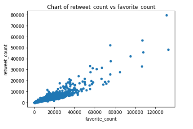

#### Bar Chart

The bar chart depicts a graphical distribution of the various dog stages;

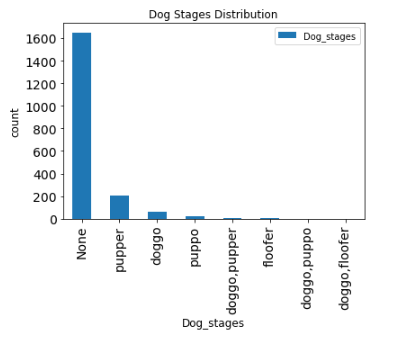